# Mineria de Datos I

- El índice de Youden es de -> (0.73 + 0.76) - 1 = 0.49

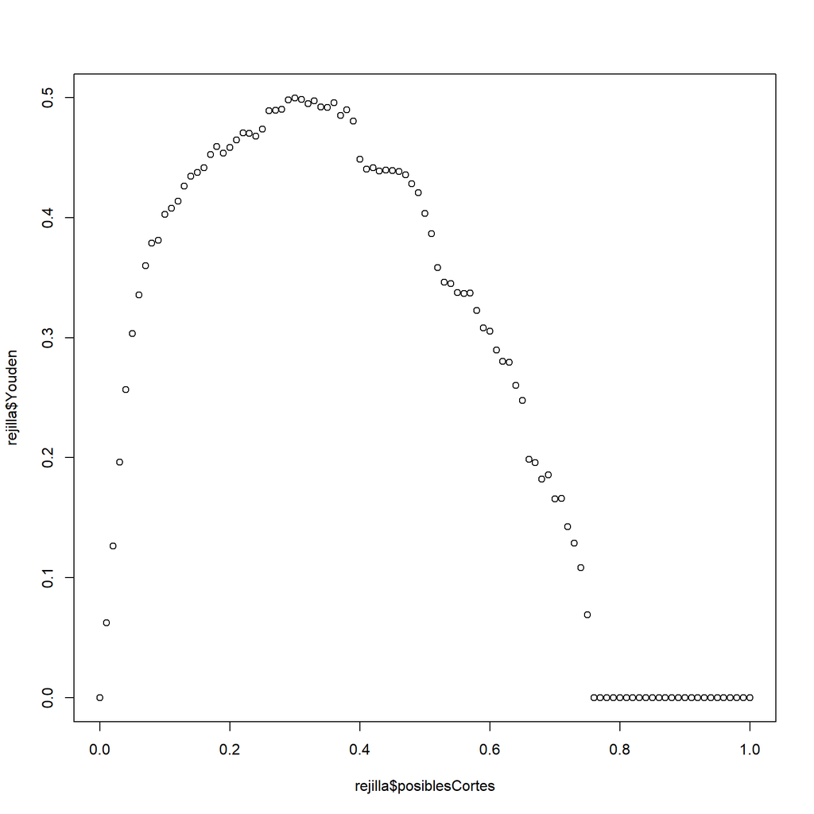

```r
posiblesCortes<-seq(0,1,0.01)
rejilla<-data.frame(t(rbind(posiblesCortes,sapply(posiblesCortes,function(x) sensEspCorte(modelo4,data_test,"varObjBin",x,"1")))))
rejilla$Youden<-rejilla$Sensitivity+rejilla$Specificity-1
plot(rejilla$posiblesCortes,rejilla$Youden)
```

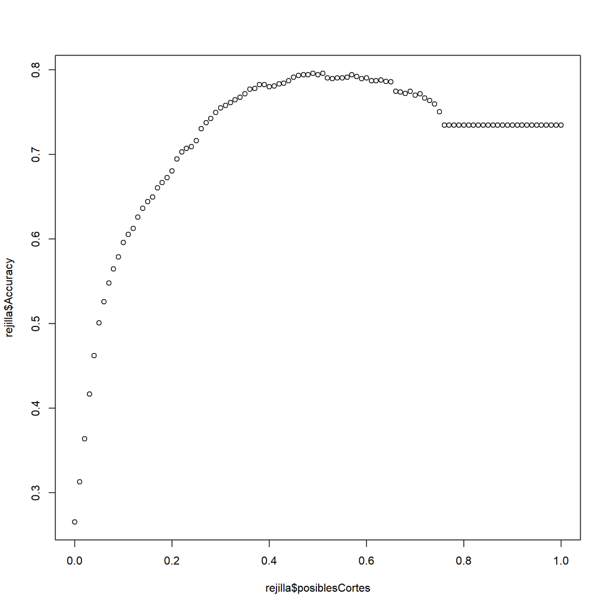

```r
plot(rejilla$posiblesCortes,rejilla$Accuracy)
```

```r
rejilla$posiblesCortes[which.max(rejilla$Youden)]
```

```
## [1] 0.3
```

```r
rejilla$posiblesCortes[which.max(rejilla$Accuracy)]
```

```
## [1] 0.49
```

Vamos a implementar este punto de corte más óptimo pero seguramente el modelo no cambie nada.

```r
sensEspCorte(modelo4,data_test,"varObjBin",0.31,"1")
```

```
##       Accuracy    Sensitivity    Specificity Pos Pred Value Neg Pred Value
##      0.7582677      0.7299703      0.7684887      0.5324675      0.8873762
```

```r
sensEspCorte(modelo4,data_test,"varObjBin",0.5,"1")
```

```
##       Accuracy    Sensitivity    Specificity Pos Pred Value Neg Pred Value
##      0.7944882      0.5044510      0.8992497      0.6439394      0.8339960
```

hallado!!)

```r
coef(modelo4)
```

```
##         (Intercept) Int_servFiber optic          Int_servNo       Antig.fc.edad
##         -0.40871695          1.08044266         -0.88942140         -0.03299805
##    ContratoOne year    ContratoTwo year        SeguridadYes    Fact_sinPapelYes
##         -0.76780411         -1.44807774         -0.56818788          0.46867997
```

Observamos que hay variables que aportan de forma positiva y otras de forma negativa, concretamente hay muchas más negativas que positivas.

```r
pseudoR2(modelo4,data_train,"varObjBin")
```

```
## [1] 0.2626548
```

```r
pseudoR2(modelo4,data_test,"varObjBin")
```

```
## [1] 0.2406296
```

```r
roc(data_train$varObjBin, predict(modelo4,data_train,type = "response"), direction="<")
```

```
##
## Call:
## roc.default(response = data_train$varObjBin, predictor = predict(modelo4,     data_train, type = "response"), direction = "<")
##
## Data: predict(modelo4, data_train, type = "response") in 3734 controls (data_train$varObjBin 0) < 1349 cases (data_train$varObjBin 1).
## Area under the curve: 0.8363
```

```r
roc(data_test$varObjBin, predict(modelo4,data_test,type = "response"), direction="<")
```

```
##
## Call:
## roc.default(response = data_test$varObjBin, predictor = predict(modelo4,     data_test, type = "response"), direction = "<")
##
## Data: predict(modelo4, data_test, type = "response") in 933 controls (data_test$varObjBin 0) < 337 cases (data_test$varObjBin 1).
## Area under the curve: 0.8245
```

```r
sensEspCorte(modelo4,data_train,"varObjBin",0.31,"1")
```

```
##       Accuracy    Sensitivity    Specificity Pos Pred Value Neg Pred Value
##      0.7593941      0.7420311      0.7656668      0.5335821      0.8914874
```

```r
sensEspCorte(modelo4,data_test,"varObjBin",0.31,"1")
```

```
##       Accuracy    Sensitivity    Specificity Pos Pred Value Neg Pred Value
##      0.7582677      0.7299703      0.7684887      0.5324675      0.8873762
```

```r
pred_test<-factor(ifelse(predict(modelo4,data_test,type = "response")>0.31,1,0))
```

```r
table(pred_test)
```

```
## pred_test
##   0   1
## 808 462
```

```r
table(data_test$varObjBin)
```

```
##
##   0   1
## 933 337
```

```r
confusionMatrix(pred_test,data_test$varObjBin, positive = '1')
```

```
## Confusion Matrix and Statistics
##
##           Reference
## Prediction   0   1
##          0 717  91
##          1 216 246
##
##                Accuracy : 0.7583
##                  95% CI : (0.7337, 0.7816)
##     No Information Rate : 0.7346
##     P-Value [Acc > NIR] : 0.02951
##
##                   Kappa : 0.4457
##
##  Mcnemar's Test P-Value : 1.473e-12
##
##             Sensitivity : 0.7300
##             Specificity : 0.7685
##          Pos Pred Value : 0.5325
##          Neg Pred Value : 0.8874
##              Prevalence : 0.2654
##          Detection Rate : 0.1937
##    Detection Prevalence : 0.3638
##       Balanced Accuracy : 0.7492
##
##        'Positive' Class : 1
##
```

> Interpretación de los parámetros

```r
todo$varObjBin <- varObjBin
```

```r
modeloC<-glm(formula(modelo4),data=todo,family=binomial)
summary(modeloC)
```

```
##
## Call:
## glm(formula = formula(modelo4), family = binomial, data = todo)
##
## Deviance Residuals:
##     Min       1Q   Median       3Q      Max
## -1.6666  -0.6780  -0.3243   0.7575   3.0717
##
## Coefficients:
##                      Estimate Std. Error z value Pr(>|z|)
## (Intercept)         -0.421482   0.083779  -5.031 4.88e-07 ***
## Int_servFiber optic  1.075816   0.077869  13.816  < 2e-16 ***
## Int_servNo          -1.006515   0.123840  -8.128 4.38e-16 ***
## Antig.fc.edad       -0.033130   0.002012 -16.467  < 2e-16 ***
## ContratoOne year    -0.699056   0.103223  -6.772 1.27e-11 ***
## ContratoTwo year    -1.325904   0.150178  -8.829  < 2e-16 ***
## SeguridadYes        -0.522197   0.086984  -6.003 1.93e-09 ***
## Fact_sinPapelYes     0.480662   0.075472   6.369 1.91e-10 ***
## ---
## Signif. codes:  0 '***' 0.001 '**' 0.01 '*' 0.05 '.' 0.1 ' ' 1
##
## (Dispersion parameter for binomial family taken to be 1)
##
##     Null deviance: 7351.9  on 6352  degrees of freedom
## Residual deviance: 5450.5  on 6345  degrees of freedom
## AIC: 5466.5
##
## Number of Fisher Scoring iterations: 6
```

```r
epiDisplay::logistic.display(modeloC)
```

```
##
## Logistic regression predicting varObjBin : 1 vs 0
##
##                               crude OR(95%CI)   adj. OR(95%CI)
## Int_serv: ref.=DSL
##    Fiber optic                3.06 (2.68,3.49)  2.93 (2.52,3.42)
##    No                         0.38 (0.3,0.47)   0.37 (0.29,0.47)
##
## Antig.fc.edad (cont. var.)    0.96 (0.96,0.96)  0.97 (0.96,0.97)
##
## Contrato: ref.=Month-to-month
##    One year                   0.19 (0.16,0.23)  0.5 (0.41,0.61)
##    Two year                   0.06 (0.05,0.08)  0.27 (0.2,0.36)
##
## Seguridad: Yes vs No          0.36 (0.32,0.42)  0.59 (0.5,0.7)
##
## Fact_sinPapel: Yes vs No      2.54 (2.25,2.88)  1.62 (1.39,1.87)
##
##                               P(Wald's test) P(LR-test)
## Int_serv: ref.=DSL                           < 0.001
##    Fiber optic                < 0.001
##    No                         < 0.001
##
## Antig.fc.edad (cont. var.)    < 0.001        < 0.001
##
## Contrato: ref.=Month-to-month                < 0.001
##    One year                   < 0.001
##    Two year                   < 0.001
##
## Seguridad: Yes vs No          < 0.001        < 0.001
##
## Fact_sinPapel: Yes vs No      < 0.001        < 0.001
##
## Log-likelihood = -2725.2353
## No. of observations = 6353
## AIC value = 5466.4707
```

## 11) Construcción del dataset de entrega con el ID y Fuga_pred

```r
test_id <- df_test$ID
df_test <- df_test[,-1]
```

```r
df_test <- data.frame(df_test)
```

```r
df_test$Antig.fc.edad <- df_test$Antiguedad
```

```r
df_test <- df_test[,-5]
```

```r
str(df_test)
```

```
## 'data.frame':    690 obs. of  19 variables:
##  $ Genero         : chr  "Female" "Male" "Male" "Female" ...
##  $ Mayor65        : num  0 1 0 0 0 0 0 0 0 1 ...
##  $ Conyuge        : chr  "No" "No" "Yes" "Yes" ...
##  $ PersCargo      : chr  "No" "No" "No" "Yes" ...
##  $ Telf_serv      : chr  "Yes" "No" "Yes" "Yes" ...
##  $ VariasLineas   : chr  "No" "No" "No" "Yes" ...
##  $ Int_serv       : chr  "Fiber optic" "DSL" "No" "Fiber optic" ...
##  $ Seguridad      : chr  "No" "No" "No" "Yes" ...
##  $ CopiaSeguridad : chr  "Yes" "No" "No" "Yes" ...
##  $ Antivirus_disp : chr  "Yes" "Yes" "No" "No" ...
##  $ Soporte_tecnico: chr  "No" "No" "No" "Yes" ...
##  $ TV_streaming   : chr  "No" "No" "No" "Yes" ...
##  $ Peliculas      : chr  "Yes" "Yes" "No" "No" ...
##  $ Contrato       : chr  "Month-to-month" "Month-to-month" "One year" "Two year" ...
##  $ Fact_sinPapel  : chr  "Yes" "Yes" "No" "No" ...
##  $ MetodoPago     : chr  "Electronic check" "Electronic check" "Bank transfer (automatic)" "Bank transfer (automatic)" ...
##  $ FacturaMes     : num  90 39.6 19.8 99.9 20.8 ...
##  $ FacturaTotal   : num  1862.9 39.6 202.2 7251.7 418.2 ...
##  $ Antig.fc.edad  : num  21 1 12 72 17 9 8 66 71 25 ...
```

```r
names(df_test)
```

```
##  [1] "Genero"          "Mayor65"         "Conyuge"         "PersCargo"
##  [5] "Telf_serv"       "VariasLineas"    "Int_serv"        "Seguridad"
##  [9] "CopiaSeguridad"  "Antivirus_disp"  "Soporte_tecnico" "TV_streaming"
## [13] "Peliculas"       "Contrato"        "Fact_sinPapel"   "MetodoPago"
## [17] "FacturaMes"      "FacturaTotal"    "Antig.fc.edad"
```

```r
columnas_cat <- c("Genero", "Mayor65", "Conyuge", "PersCargo", "Telf_serv", "VariasLineas", "Int_serv", "Seguridad","CopiaSeguridad",
                  "Antivirus_disp", "Soporte_tecnico", "TV_streaming", "Peliculas", "Contrato", "Fact_sinPapel", "MetodoPago")
```

```r
df_test[columnas_cat] <- lapply(df_test[columnas_cat], factor)
```

```r
predicciones <- predict(modelo4, newdata = df_test)
predicciones_binarias <- ifelse(predicciones >= 0.5, 1, 0)
```

```r
datos_entrega <- cbind(Id = test_id, Fuga_pred = predicciones_binarias)
datos_entrega <- data.frame(datos_entrega)
```

```r
saveRDS(datos_entrega, file = "C:/Users/xikix/Downloads/Mineria de datos 1/FugaPredict_Gerard_Chicot_Navalls.rds")
file.exists("FugaPredict_Gerard_Chicot_Navalls.rds")
```

```
## [1] TRUE
```

Podemos ver en este último apartado como he transformado todo el df_test de la misma forma que tenemso el dataframe creado para modelizar. De esta manera podemos utilizar el modelo que mejor resultado nos ha dado para su predicción.